# Week 4 - Workshop 2: joins - solution

08/04/2020

```r
library(tidyverse)
gap_life <- read_csv("data/gap_life.csv")
gap_life_au <- read_csv("data/gap_life_au.csv")
gap_income <- read_csv("data/gap_income.csv")
gap_income_au <- read_csv("data/gap_income_au.csv")
gap_co2 <- read_csv("data/gap_co2.csv")
gap_co2_au <- read_csv("data/gap_co2_au.csv")
```

# Section A: Understanding joins

We have information on Australian life expectancy and income:

```r
gap_life_au
```

```
## # A tibble: 9 x 3
##   country    year life_expectancy
##   <chr>     <dbl>           <dbl>
## 1 Australia  2012            82.5
## 2 Australia  2013            82.6
## 3 Australia  2014            82.5
## 4 Australia  2015            82.5
## 5 Australia  2016            82.5
## 6 Australia  2017            82.4
## 7 Australia  2018            82.5
## 8 Australia  2019            82.7
## 9 Australia  2020            82.8
```

```r
gap_income_au
```

```
## # A tibble: 9 x 3
##   country    year   gdp
##   <chr>     <dbl> <dbl>
## 1 Australia  2012 42800
## 2 Australia  2013 43200
## 3 Australia  2014 43700
## 4 Australia  2015 44100
## 5 Australia  2016 44600
## 6 Australia  2017 44900
## 7 Australia  2018 45400
## 8 Australia  2019 45500
## 9 Australia  2020 45800
```

How do we plot life expectancy against income? We need them in the same dataframe

One technique that we’ve looked at is `bind_cols()`, which binds dataframes together, column wise

```r
bind_cols(gap_life_au,
          gap_income_au)
```

```
## * country -> country...1
## * year -> year...2
## * country -> country...4
## * year -> year...5
```

```
## # A tibble: 9 x 6
##   country...1 year...2 life_expectancy country...4 year...5   gdp
##   <chr>          <dbl>           <dbl> <chr>          <dbl> <dbl>
## 1 Australia       2012            82.5 Australia       2012 42800
## 2 Australia       2013            82.6 Australia       2013 43200
## 3 Australia       2014            82.5 Australia       2014 43700
## 4 Australia       2015            82.5 Australia       2015 44100
## 5 Australia       2016            82.5 Australia       2016 44600
## 6 Australia       2017            82.4 Australia       2017 44900
## 7 Australia       2018            82.5 Australia       2018 45400
## 8 Australia       2019            82.7 Australia       2019 45500
## 9 Australia       2020            82.8 Australia       2020 45800
```

But this has problems:

1. It produces messy output (country1, year1)
2. It doesn’t work if the data doesn’t have the same number of rows

For example, how do we add this co2 data to income or life?

```r
gap_co2_au
```

```
## # A tibble: 3 x 3
##   country    year   co2
##   <chr>     <dbl> <dbl>
## 1 Australia  2012  17
## 2 Australia  2013  16.1
## 3 Australia  2014  15.4
```

We can’t use `bind_cols()`

```r
bind_cols(gap_co2_au,
          gap_income_au)
```

[output not shown]

We could think about a more complex approach using `filter`, and so on…

But surely this must be a problem that we encounter in data analysis?

Someone must have thought of a solution to this before?

They did! Joins!

We can use `left_join()` to combine the income and life expectancy data

```r
left_join(x = gap_income_au,
          y = gap_life_au,
          by = c("country", "year"))
```

```
## # A tibble: 9 x 4
##   country    year   gdp life_expectancy
##   <chr>     <dbl> <dbl>           <dbl>
## 1 Australia  2012 42800            82.5
## 2 Australia  2013 43200            82.6
## 3 Australia  2014 43700            82.5
## 4 Australia  2015 44100            82.5
## 5 Australia  2016 44600            82.5
## 6 Australia  2017 44900            82.4
## 7 Australia  2018 45400            82.5
## 8 Australia  2019 45500            82.7
## 9 Australia  2020 45800            82.8
```

And then what about adding co2 data?

We can add on another join:

```r
left_join(x = gap_income_au,
          y = gap_life_au,
          by = c("country", "year")) %>%
  left_join(gap_co2_au,
            by = c("country", "year"))
```

```
## # A tibble: 9 x 5
##   country    year   gdp life_expectancy   co2
##   <chr>     <dbl> <dbl>           <dbl> <dbl>
## 1 Australia  2012 42800            82.5  17
## 2 Australia  2013 43200            82.6  16.1
## 3 Australia  2014 43700            82.5  15.4
## 4 Australia  2015 44100            82.5  NA
## 5 Australia  2016 44600            82.5  NA
## 6 Australia  2017 44900            82.4  NA
## 7 Australia  2018 45400            82.5  NA
## 8 Australia  2019 45500            82.7  NA
## 9 Australia  2020 45800            82.8  NA
```

And we get some missing values for co2, because we don’t have c02 values for 2015 and beyond.

So now we can combine that together like so:

```r
gap_au <- left_join(x = gap_income_au,
          y = gap_life_au,
          by = c("country", "year")) %>%
  left_join(gap_co2_au,
            by = c("country", "year"))

gap_au
```

```
## # A tibble: 9 x 5
##   country    year   gdp life_expectancy   co2
##   <chr>     <dbl> <dbl>           <dbl> <dbl>
## 1 Australia  2012 42800            82.5  17
## 2 Australia  2013 43200            82.6  16.1
## 3 Australia  2014 43700            82.5  15.4
## 4 Australia  2015 44100            82.5  NA
## 5 Australia  2016 44600            82.5  NA
## 6 Australia  2017 44900            82.4  NA
## 7 Australia  2018 45400            82.5  NA
## 8 Australia  2019 45500            82.7  NA
## 9 Australia  2020 45800            82.8  NA
```

Now we can make a plot!

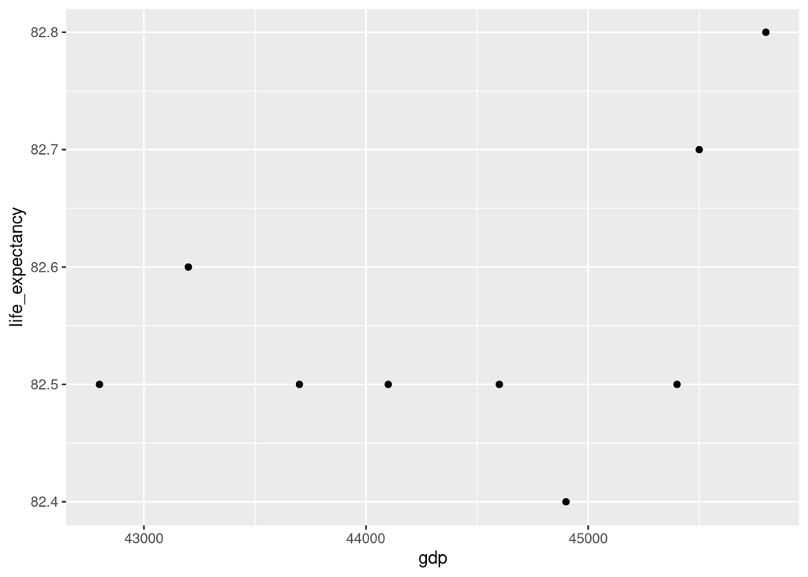

```r
ggplot(gap_au,
       aes(x = gdp,
           y = life_expectancy)) +
  geom_point()
```

# Section B

## Q1

Write down why these two joins produce different results:

```r
left_join(gap_co2_au,
          gap_life_au)
```

```
## # A tibble: 3 x 4
##   country    year   co2 life_expectancy
##   <chr>     <dbl> <dbl>           <dbl>
## 1 Australia  2012  17              82.5
## 2 Australia  2013  16.1            82.6
## 3 Australia  2014  15.4            82.5
```

```r
left_join(gap_life_au,
          gap_co2_au)
```

```
## # A tibble: 9 x 4
##   country    year life_expectancy   co2
##   <chr>     <dbl>           <dbl> <dbl>
## 1 Australia  2012            82.5  17
## 2 Australia  2013            82.6  16.1
## 3 Australia  2014            82.5  15.4
## 4 Australia  2015            82.5  NA
## 5 Australia  2016            82.5  NA
## 6 Australia  2017            82.4  NA
## 7 Australia  2018            82.5  NA
## 8 Australia  2019            82.7  NA
## 9 Australia  2020            82.8  NA
```

**Answer:**

In the first line of the code chunk above, we perform a left join between gap_co2_au and gap_life_au. A left join will use gap_co2_au as the master table to which the gap_life_au records are joined. So because gap_co_2 only has 3 rows - then this limits the number of rows that gap_life_au can be joined to - only the rows in gap_life_au from the years 2012, 2013 and 2014 will be able to be joined.

In the second line, gap_life_au is the master to which gap_co2_au will be joined. In this case, all rows from gap_life_au are used, and the three matches from gap_co2_au are joined to this for years 2012, 2013, 2014, and the rest of the unmatched fields become NA.

## Q2

What happens when we add data from New Zealand into the mix? Can you produce a dataset that has all data on gdp, life expectancy, and co2, for both Australia and New Zealand, using the joining techniques you’ve just learnt?

```r
gap <- left_join(x = gap_income,
          y = gap_life,
          by = c("country", "year")) %>%
  left_join(gap_co2,
            by = c("country", "year"))
```